# PhyloAcc simulations

```r
knitr::opts_chunk$set(echo = TRUE, warning = FALSE, message = FALSE)

library(ggplot2)
library(dplyr)
library(cowplot)
library(ggtree)
library(phangorn)
library(ape)
library(kableExtra)
library(ggbeeswarm)
library(ggsignif)
library(here)
source("../lib/design.r")
source("../lib/get_tree_info.r")
```

```r
treefile = here("docs", "data", "ratite-sim.tre")
sim_tree = read.tree(treefile)
tree_to_df_list = treeToDF(sim_tree)
sim_tree_info = tree_to_df_list[["info"]]
# Read the tree and parse with treetoDF

sim_tree_info = sim_tree_info[order(sim_tree_info$node), ]
# Re-sort the data frame by R node order after the merge so the trees still work

#tree_info_file = here("docs", "data", "ratite-sim.csv")
#write.csv(file=tree_info_file, sim_tree_info, row.names=F)
# Write the tree info to a csv

sim_info_file = here("docs", "data", "ratite-sim-cases.csv")
sim_info = read.csv(sim_info_file, header=T)
# Read the tree info with simulation cases
```

# 1 Simulations

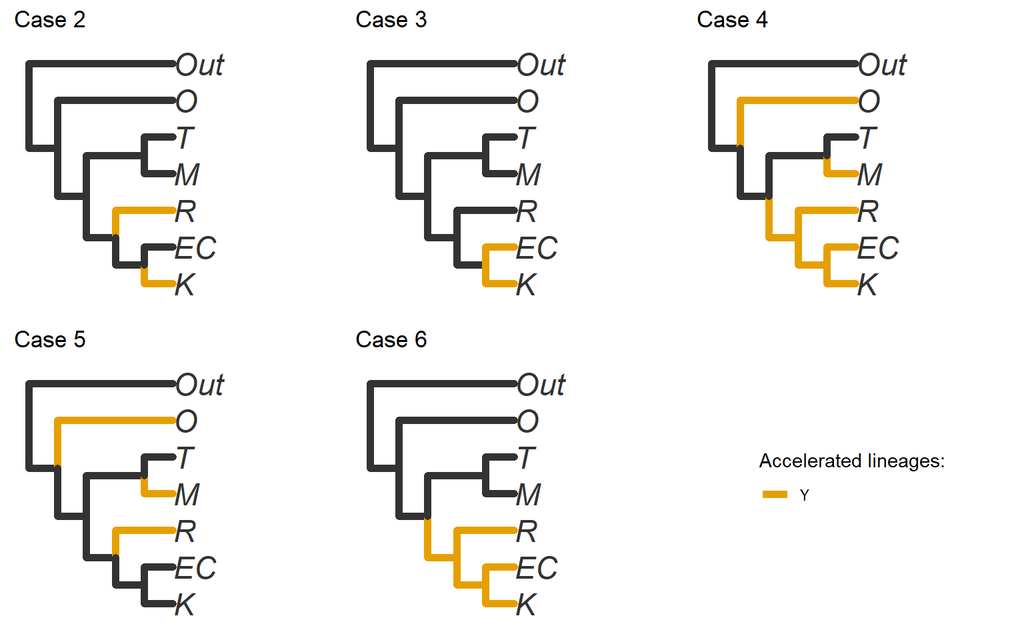

```r
sim_cols = c("N"="#333333", "Y"=corecol(pal="wilke", numcol=1))

plot_sim_tree = function (tree, data, case) {
  case_str = paste("Case.", case, sep="")
  #print(case_str)

  ggtree(tree, size=2, ladderize=F, aes(color=data[[case_str]])) +
  #tree_p = ggtree(sim_tree, size=2, ladderize=F, aes_string(data=sim_info, color=case_str)) +
    xlim(0,10) +
    #scale_color_manual(name='Accelerated?', values=corecol(pal="wilke", numcol=2)) +
    scale_color_manual(name='Accelerated lineages:', values=sim_cols, breaks=c("Y")) +
    geom_tiplab(color="#333333", fontface='italic', size=6) +
    ggtitle(paste("Case", case)) +
    theme(legend.position=c(0.5,0.5))
  # Option to add branch labels to the figure
}
# Function to plot a tree

rm_legend = function(legend_p){
  legend_p + theme(legend.position="none")
}
# Function to remove a legend from a plot

cases = c(2,3,4,5,6)
tree_figs1 = lapply(cases, plot_sim_tree, tree=sim_tree, data=sim_info)
# Plot trees for each of the 5 simulation cases and save them in a list

legend = get_legend(tree_figs1[[1]])
# Get the legend from one of the tree figures

tree_figs = lapply(tree_figs1, rm_legend)
# Remove the legends from the individual tree figures

tree_figs[[6]] = legend
# Add the legend previously retrieved as its own figure in the list of figures

p = plot_grid(plotlist=tree_figs, ncol=3, nrow=2)
print(p)
```

```r
# Combine the tree figures and legend and output
```

By testing the effects of different simulated lineages with different target regimes we should be able to assess the performance of PhyloAcc.

# 2 Monophyletic acceleration

Case 3 above represents acceleration in a monophyletic clade. Here, the branch colors correspond to how the branch was simulated. Branches with green stars above them are those that would be specified as target lineages when running PhyloAcc.

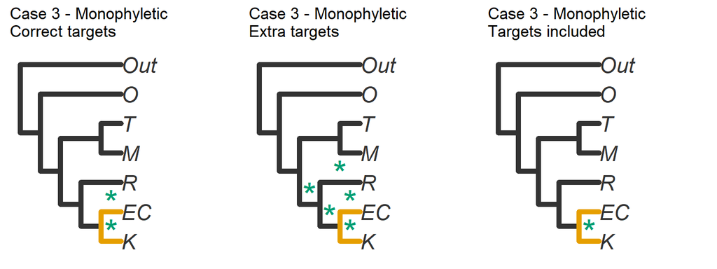

```r
plot_target_tree = function (tree, data, case, targets) {

  case_str = paste("Case.", case, sep="")
  #print(case_str)

  target_str = paste("case", case, ".targets.", targets, sep="")
  #print(target_str)

  title = paste("Case", case, "- Monophyletic")
  if(targets == 1){
    title = paste(title, "\nCorrect targets")
  }else if(targets == 2){
    title = paste(title, "\nExtra targets")
  }else if(targets == 3){
    title = paste(title, "\nTargets included")
  }

  ggtree(tree, size=2, ladderize=F, aes(color=data[[case_str]])) +
    xlim(0,10) +
    scale_color_manual(name='Accelerated lineages:', values=sim_cols, breaks=c("Y")) +
    #scale_color_manual(name='Accelerated?', values=corecol(pal="wilke", numcol=2)) +
    geom_tiplab(color="#333333", fontface='italic', size=6) +
    geom_label(aes(x=branch, label=ifelse(data[[target_str]]=="Y","*",NA)), label.size=NA, size=10, fill="transparent", color=corecol(pal="wilke", numcol=1, offset=2), show.legend=F, vjust=0.3) +
    ggtitle(title) +
    theme(legend.position="none")
  # Option to add branch labels to the figure

}
# Function to plot a tree

targets = c(1,2,3)
tree_figs = lapply(targets, plot_target_tree, case=3, tree=sim_tree, data=sim_info)
# Plot trees for each of the 5 simulation cases and save them in a list


p = plot_grid(plotlist=tree_figs, ncol=3, nrow=1)
print(p)
```

```r
# Combine the tree figures and legend and output
```

1. The leftmost panel represents using the branches simulated as accelerated in Case 3 and specifying those same target lineages.
   - Mentioned when comparing logBF1 (FIgure 2 AUPRC), probability of acceleration P(Z=2|Y) (Figure 3 boxplots), logBF1 while varying theta (Figure 5 AUPRC), and probability of acceleration P(Z=2|Y) while varying theta (Figure 6 boxplots, Figure 7 lineplots), and TP and TN rates (Table 2)
2. The middle panel represents using the branches simulated as accelerated in Case 3 and specifying the lineages from Case 6 as targets.
   - Not mentioned
3. The middle panel represents using the branches simulated as accelerated in Case 3 and specifying only K as targets.
   - Not mentioned

# 3 Paraphyletic acceleration

Case 4 above represents acceleration in a paraphyletic clade. Here, the branch colors correspond to how the branch was simulated. Branches with green stars above them are those that would be specified as target lineages when running PhyloAcc.

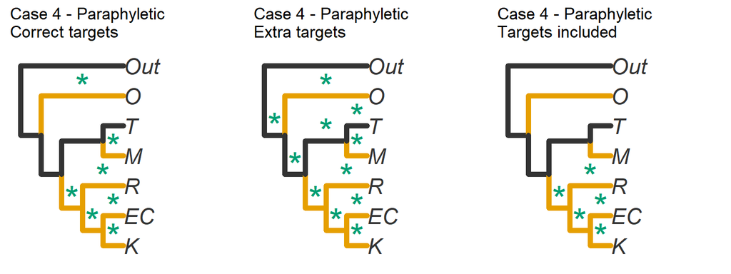

```r
plot_target_tree = function (tree, data, case, targets) {

  case_str = paste("Case.", case, sep="")
  #print(case_str)

  target_str = paste("case", case, ".targets.", targets, sep="")
  #print(target_str)

  title = paste("Case", case, "- Paraphyletic")
  if(targets == 1){
    title = paste(title, "\nCorrect targets")
  }else if(targets == 2){
    title = paste(title, "\nExtra targets")
  }else if(targets == 3){
    title = paste(title, "\nTargets included")
  }

  ggtree(tree, size=2, ladderize=F, aes(color=data[[case_str]])) +
    xlim(0,10) +
    scale_color_manual(name='Accelerated lineages:', values=sim_cols, breaks=c("Y")) +
    #scale_color_manual(name='Accelerated?', values=corecol(pal="wilke", numcol=2)) +
    geom_tiplab(color="#333333", fontface='italic', size=6) +
    geom_label(aes(x=branch, label=ifelse(data[[target_str]]=="Y","*",NA)), label.size=NA, size=10, fill="transparent", color=corecol(pal="wilke", numcol=1, offset=2), show.legend=F, vjust=0.3) +
    ggtitle(title) +
    theme(legend.position="none")
  # Option to add branch labels to the figure

}
# Function to plot a tree

targets = c(1,2,3)
tree_figs = lapply(targets, plot_target_tree, case=4, tree=sim_tree, data=sim_info)
# Plot trees for each of the 5 simulation cases and save them in a list


p = plot_grid(plotlist=tree_figs, ncol=3, nrow=1)
print(p)
```

```r
# Combine the tree figures and legend and output
```

1. The leftmost panel represents using the branches simulated as accelerated in Case 4 and specifying those same target lineages.
   - Mentioned when comparing logBF1 (Figure 2 AUPRC), probability of acceleration P(Z=2|Y) (Figure 3 boxplots), and logBF1 while varying theta (Figure 5 AUPRC)
2. The middle panel represents using the branches simulated as accelerated in Case 4 and specifying the lineages from Case 4 + T as targets.
   - Not mentioned
3. The middle panel represents using the branches simulated as accelerated in Case 4 and specifying the lineages from Case 6 as targets.
   - Not mentioned

# 4 Convergent acceleration

Case 2 above represents convergent acceleration in multiple lineages. Here, the branch colors correspond to how the branch was simulated. Branches with green stars above them are those that would be specified as target lineages when running PhyloAcc.

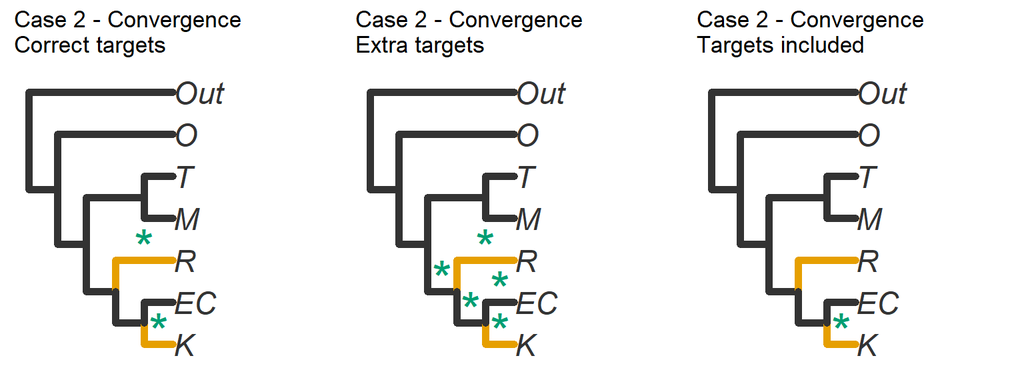

```r
plot_target_tree = function (tree, data, case, targets) {

  case_str = paste("Case.", case, sep="")
  #print(case_str)

  target_str = paste("case", case, ".targets.", targets, sep="")
  #print(target_str)

  title = paste("Case", case, "- Convergence")
  if(targets == 1){
    title = paste(title, "\nCorrect targets")
  }else if(targets == 2){
    title = paste(title, "\nExtra targets")
  }else if(targets == 3){
    title = paste(title, "\nTargets included")
  }

  ggtree(tree, size=2, ladderize=F, aes(color=data[[case_str]])) +
    xlim(0,10) +
    scale_color_manual(name='Accelerated lineages:', values=sim_cols, breaks=c("Y")) +
    #scale_color_manual(name='Accelerated?', values=corecol(pal="wilke", numcol=2)) +
    geom_tiplab(color="#333333", fontface='italic', size=6) +
    geom_label(aes(x=branch, label=ifelse(data[[target_str]]=="Y","*",NA)), label.size=NA, size=10, fill="transparent", color=corecol(pal="wilke", numcol=1, offset=2), show.legend=F, vjust=0.3) +
    ggtitle(title) +
    theme(legend.position="none")
  # Option to add branch labels to the figure

}
# Function to plot a tree

targets = c(1,2,3)
tree_figs = lapply(targets, plot_target_tree, case=2, tree=sim_tree, data=sim_info)
# Plot trees for each of the 5 simulation cases and save them in a list


p = plot_grid(plotlist=tree_figs, ncol=3, nrow=1)
print(p)
```

```r
# Combine the tree figures and legend and output
```

1. The leftmost panel represents using the branches simulated as accelerated in Case 2 and specifying those same target lineages.
   - Mentioned when comparing logBF1 (FIgure 2 AUPRC), probability of acceleration P(Z=2|Y) (Figure 3 boxplots), logBF1 while varying theta (Figure 5 AUPRC), and probability of acceleration P(Z=2|Y) while varying theta (Figure 7 lineplots), and TP and TN rates (Table 2)
2. The middle panel represents using the branches simulated as accelerated in Case 2 and specifying the lineages from Case 6 as targets.
   - Not mentioned
3. The middle panel represents using the branches simulated as accelerated in Case 2 and specifying only K as the target lineage.
   - Not Mentioned

# 5 Other comparisons mentioned in the paper

### 5.0.1 Figure 2

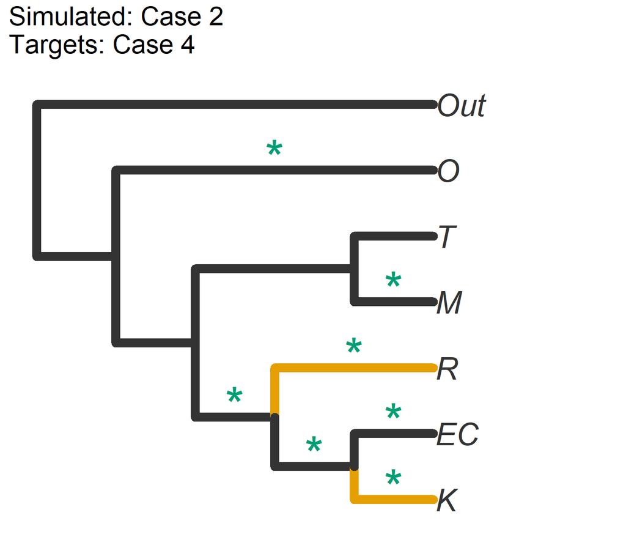

```r
case = 2
targets = 4
case_str = paste("Case.", case, sep="")
target_str = paste("Case.", targets, sep="")
title = paste("Simulated: Case ", case, "\nTargets: Case ", targets, sep="")
tree_fig = ggtree(sim_tree, size=4, ladderize=F, aes(color=sim_info[[case_str]])) +
  xlim(0,7) +
  scale_color_manual(name='Accelerated lineages:', values=sim_cols, breaks=c("Y")) +
  #scale_color_manual(name='Accelerated?', values=corecol(pal="wilke", numcol=2)) +
  geom_tiplab(color="#333333", fontface='italic', size=10) +
  geom_label(aes(x=branch, label=ifelse(sim_info[[target_str]]=="Y","*",NA)), label.size=NA, size=16, fill="transparent", color=corecol(pal="wilke", numcol=1, offset=2), show.legend=F, vjust=0.3) +
  ggtitle(title) +
  theme(legend.position="none", plot.title=element_text(size=24))
# Option to add branch labels to the figure
print(tree_fig)
```

```r
###############
```

### 5.0.2 Table 1, Figure 4

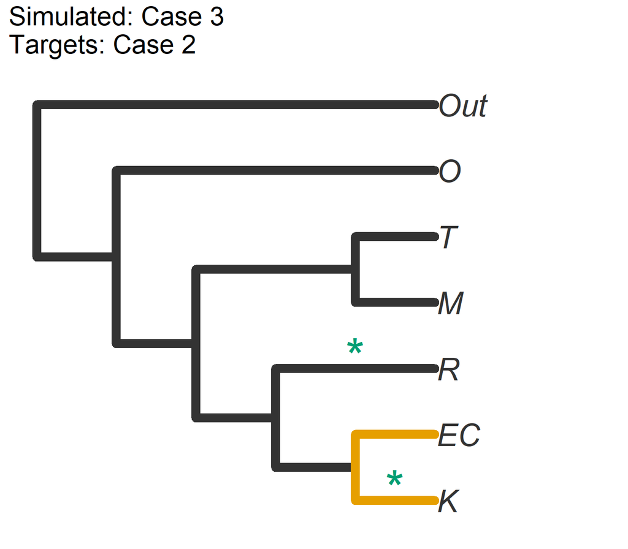

```r
case = 3
targets = 2
case_str = paste("Case.", case, sep="")
target_str = paste("Case.", targets, sep="")
title = paste("Simulated: Case ", case, "\nTargets: Case ", targets, sep="")
tree_fig = ggtree(sim_tree, size=4, ladderize=F, aes(color=sim_info[[case_str]])) +
  xlim(0,7) +
  scale_color_manual(name='Accelerated lineages:', values=sim_cols, breaks=c("Y")) +
  #scale_color_manual(name='Accelerated?', values=corecol(pal="wilke", numcol=2)) +
  geom_tiplab(color="#333333", fontface='italic', size=10) +
  geom_label(aes(x=branch, label=ifelse(sim_info[[target_str]]=="Y","*",NA)), label.size=NA, size=16, fill="transparent", color=corecol(pal="wilke", numcol=1, offset=2), show.legend=F, vjust=0.3) +
  ggtitle(title) +
  theme(legend.position="none", plot.title=element_text(size=24))
# Option to add branch labels to the figure
print(tree_fig)
```

```r
###############
```

### 5.0.3 Table 1, Figure 4

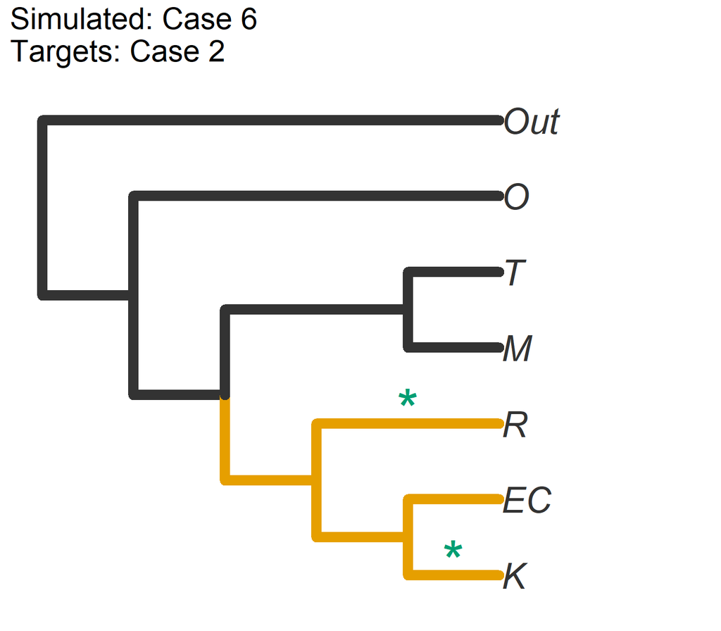

```r
case = 6
targets = 2
case_str = paste("Case.", case, sep="")
target_str = paste("Case.", targets, sep="")
title = paste("Simulated: Case ", case, "\nTargets: Case ", targets, sep="")
tree_fig = ggtree(sim_tree, size=4, ladderize=F, aes(color=sim_info[[case_str]])) +
  xlim(0,7) +
  scale_color_manual(name='Accelerated lineages:', values=sim_cols, breaks=c("Y")) +
  #scale_color_manual(name='Accelerated?', values=corecol(pal="wilke", numcol=2)) +
  geom_tiplab(color="#333333", fontface='italic', size=10) +
  geom_label(aes(x=branch, label=ifelse(sim_info[[target_str]]=="Y","*",NA)), label.size=NA, size=16, fill="transparent", color=corecol(pal="wilke", numcol=1, offset=2), show.legend=F, vjust=0.3) +
  ggtitle(title) +
  theme(legend.position="none", plot.title=element_text(size=24))
# Option to add branch labels to the figure
print(tree_fig)
```

```r
###############
```

### 5.0.4 Table 1, Figure 4

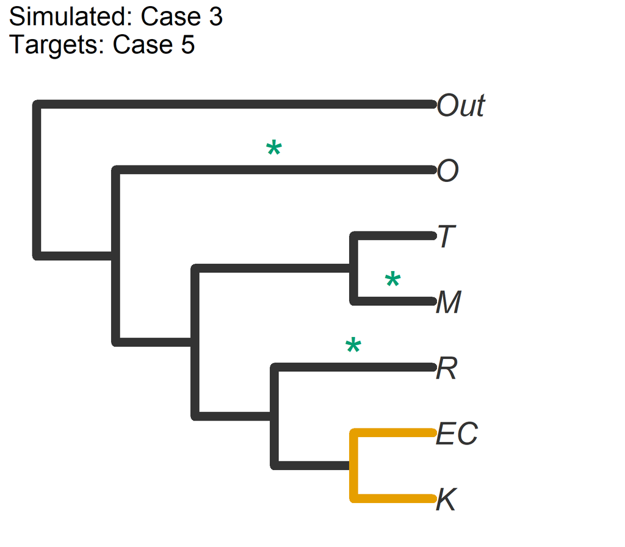

```r
case = 3
targets = 5
case_str = paste("Case.", case, sep="")
target_str = paste("Case.", targets, sep="")
title = paste("Simulated: Case ", case, "\nTargets: Case ", targets, sep="")
tree_fig = ggtree(sim_tree, size=4, ladderize=F, aes(color=sim_info[[case_str]])) +
  xlim(0,7) +
  scale_color_manual(name='Accelerated lineages:', values=sim_cols, breaks=c("Y")) +
  #scale_color_manual(name='Accelerated?', values=corecol(pal="wilke", numcol=2)) +
  geom_tiplab(color="#333333", fontface='italic', size=10) +
  geom_label(aes(x=branch, label=ifelse(sim_info[[target_str]]=="Y","*",NA)), label.size=NA, size=16, fill="transparent", color=corecol(pal="wilke", numcol=1, offset=2), show.legend=F, vjust=0.3) +
  ggtitle(title) +
  theme(legend.position="none", plot.title=element_text(size=24))
# Option to add branch labels to the figure
print(tree_fig)
```

```r
###############
```